# CzeLex: A megastudy dataset of concreteness, imageability, age of acquisition, valence and gender ratings for 9,707 Czech words

## Summary data

### Traditional descriptive statistics

First, we calculate the mean, SD, number of responses overall, number of responses where the word was known and the proportion of known responses, for each of the words across the dimensions.

```r
czlex_summary <- czlex_norming_filtered %>%
  group_by(name, dimension) %>%
  summarise(mean = mean(value1, na.rm = TRUE),
            sd = sd(value1, na.rm = TRUE),
            n = n(),
            n_known = sum(value_known),
            prop_known = n_known/n) %>%
  arrange(dimension, name)
czlex_summary %>%
  mutate(across(where(is.numeric), ~round(., 2))) %>%
  datatable(filter = 'top')
```

|  | name | dimension | mean | sd | n | n_known | prop_known |
| --- | --- | --- | --- | --- | --- | --- | --- |
| 1 | ADHD | aoa | 14.12 | 6.59 | 26 | 26 | 1 |
| 2 | Aboridžinec | aoa | 13.6 | 1.99 | 21 | 15 | 0.71 |
| 3 | Aboridžinka | aoa | 13.23 | 2.71 | 21 | 13 | 0.62 |
| 4 | Adam | aoa | 4.82 | 2.48 | 22 | 22 | 1 |
| 5 | Adolf | aoa | 7.63 | 2.91 | 30 | 30 | 1 |
| 6 | Adéla | aoa | 4.08 | 1.61 | 24 | 24 | 1 |
| 7 | Aerolinka | aoa | 10.16 | 2.75 | 26 | 25 | 0.96 |
| 8 | AfD | aoa | 19.27 | 6.25 | 59 | 11 | 0.19 |
| 9 | Affleck | aoa | 14.55 | 2.67 | 56 | 31 | 0.55 |
| 10 | Afghanistán | aoa | 10 | 2.42 | 25 | 25 | 1 |

[output cut: 47513 more lines]

We will create a summary table in a wide format.

```r
czlex_summary_wide <- czlex_summary %>%
  ungroup() %>%
  pivot_wider(names_from  = dimension, values_from = c(mean, sd, n, n_known, prop_known))

czlex_summary_wide %>%
  mutate(across(where(is.numeric), ~round(., 2))) %>%
  datatable(filter = 'top')
```

|  | name | mean_aoa | mean_concreteness | mean_gender | mean_imageability | mean_valence | sd_aoa | sd_concreteness | sd_gender | sd_imageability | sd_valence | n_aoa | n_concreteness | n_gender | n_imageability | n_valence | n_known_aoa | n_known_concreteness | n_known_gender | n_known_imageability | n_known_valence | prop_known_aoa | prop_known_concreteness | prop_known_gender | prop_known_imageability | prop_known_valence |
| --- | --- | --- | --- | --- | --- | --- | --- | --- | --- | --- | --- | --- | --- | --- | --- | --- | --- | --- | --- | --- | --- | --- | --- | --- | --- | --- |
| 1 | ADHD | 14.12 | 2.73 | -0.31 | 5.16 | -0.57 | 6.59 | 1.28 | 0.84 | 1.68 | 0.96 | 26 | 26 | 51 | 25 | 51 | 26 | 26 | 51 | 25 | 51 | 1 | 1 | 1 | 1 | 1 |
| 2 | Aboridžinec | 13.6 | 4.05 | -1.23 | 4.94 | -0.06 | 1.99 | 1.28 | 0.97 | 1.95 | 0.43 | 21 | 25 | 29 | 25 | 26 | 15 | 20 | 22 | 18 | 17 | 0.71 | 0.8 | 0.76 | 0.72 | 0.65 |
| 3 | Aboridžinka | 13.23 | 4.47 | 2.52 | 5.4 | 0.35 | 2.71 | 0.83 | 0.79 | 1.76 | 0.61 | 21 | 25 | 27 | 37 | 21 | 13 | 15 | 23 | 25 | 17 | 0.62 | 0.6 | 0.85 | 0.68 | 0.81 |
| 4 | Adam | 4.82 | 2.91 | -2.53 | 4.33 | 0.65 | 2.48 | 1.69 | 0.74 | 2.42 | 1.02 | 22 | 22 | 43 | 21 | 43 | 22 | 22 | 43 | 21 | 43 | 1 | 1 | 1 | 1 | 1 |
| 5 | Adolf | 7.63 | 3.03 | -2.39 | 5.38 | -1.53 | 2.91 | 1.4 | 0.9 | 2.27 | 1.13 | 30 | 30 | 36 | 29 | 36 | 30 | 30 | 36 | 29 | 36 | 1 | 1 | 1 | 1 | 1 |
| 6 | Adéla | 4.08 | 3.33 | 2.68 | 5.42 | 0.4 | 1.61 | 1.79 | 0.62 | 2.32 | 1.01 | 24 | 24 | 50 | 24 | 50 | 24 | 24 | 50 | 24 | 50 | 1 | 1 | 1 | 1 | 1 |
| 7 | Aerolinka | 10.16 | 3.79 | 0.38 | 5.64 | 0.47 | 2.75 | 1.06 | 1.07 | 1.66 | 1.22 | 26 | 24 | 21 | 25 | 30 | 25 | 24 | 21 | 25 | 30 | 0.96 | 1 | 1 | 1 | 1 |
| 8 | AfD | 19.27 | 3.64 | -0.2 | 4.5 | -1.23 | 6.25 | 1.43 | 0.79 | 2.15 | 1.59 | 59 | 44 | 50 | 65 | 57 | 11 | 11 | 10 | 18 | 13 | 0.19 | 0.25 | 0.2 | 0.28 | 0.23 |
| 9 | Affleck | 14.55 | 4.49 | -2.03 | 5.43 | 0.67 | 2.67 | 0.79 | 1.21 | 1.98 | 1.18 | 56 | 49 | 55 | 45 | 55 | 31 | 39 | 37 | 30 | 27 | 0.55 | 0.8 | 0.67 | 0.67 | 0.49 |
| 10 | Afghanistán | 10 | 4.27 | -1.16 | 5.65 | -1.18 | 2.42 | 1.15 | 1.08 | 1.83 | 0.9 | 25 | 26 | 38 | 26 | 38 | 25 | 26 | 38 | 26 | 38 | 1 | 1 | 1 | 1 | 1 |

[output cut: 9591 more lines]

Descriptive statistics: grand mean, standard deviation, minimum and maximum per dimension

```r
czlex_summary %>%
  group_by(dimension) %>%
  summarise(Mean = mean(mean),
            SD = sd(mean),
            Min = min(mean),
            Max = max(mean))
```

| dimension | Mean | SD | Min | Max |
| --- | --- | --- | --- | --- |
| aoa | 7.93730114 | 2.8775595 | 1.629630 | 21.200000 |
| concreteness | 3.52477943 | 0.9346256 | 1.087719 | 5.000000 |
| gender | -0.14323881 | 0.9245186 | -2.923077 | 2.857143 |
| imageability | 5.44380049 | 1.0471526 | 1.368421 | 7.000000 |
| valence | 0.09920736 | 0.9613358 | -3.000000 | 2.875000 |

Visualise the summary data

```r
czlex_ratings_summary_label1 <- tibble(dimension = rep(unique(czlex_summary$dimension), 2),
                                       mean = c(0, 1, -3, 1, -3, 22, 5, 3, 7, 3),
                                       mean1a = c(rep(0, 5), rep(1, 5)),
                                       colour1 = c(rep("#2c7fb8", 5), rep("#f03b20", 5)),
                                       hjust = c(rep(0, 5), rep(1, 5)),
                                       label = c("early", "abstr", "masc", "diff","neg",
                                                     "late", "conc", "fem", "easy", "pos"),
                                       version = rep("", 10)
                                       ) %>%
  left_join(czlex_summary %>%
              group_by(dimension) %>%
              summarise(mean2 = mean(mean),
                        median = median(mean),
                        sd = sd(mean),
                        n = n())) %>%
  ungroup()
```

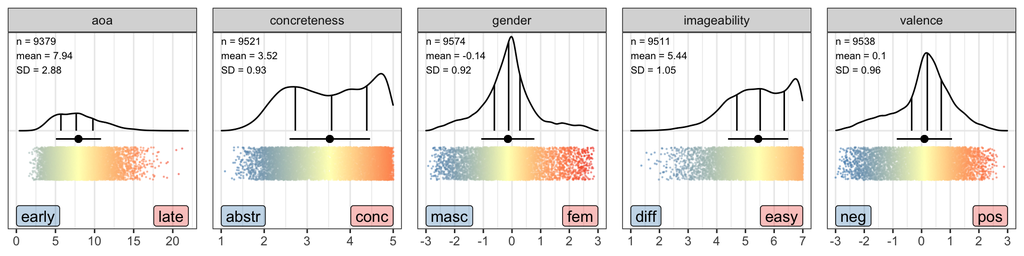

```r
czlex_ratings_summary_label1a <- tibble(
  dimension = c(rep("aoa", 5), rep("concreteness", 5), rep("gender", 7), rep("imageability", 7), rep("valence", 7)),
                                        scale1 = c(seq(0, 22, 5), seq(1, 5, 1), seq(-3, 3, 1), seq(1, 7, 1), seq(-3, 3, 1)))

for (i in unique(czlex_summary$dimension)) {

  descriptive_plot1 <- czlex_summary %>%
  mutate(version = "") %>%
  filter(dimension == i)

  czlex_ratings_summary_label2 <- czlex_ratings_summary_label1 %>%
               filter(dimension == i)

  czlex_ratings_summary_label2a <- czlex_ratings_summary_label1a %>%
               filter(dimension == i)

  descriptive_plot <- descriptive_plot1 %>%
  ggplot(aes(x = mean, y = version, colour = mean)) +
  geom_density_ridges(colour = "black",
                       fill = NA,
                       scale = 0.8,
                       quantile_lines = TRUE,
                       quantiles = c(0.25, 0.5, 0.75),
                       vline_color = c("black")) +
  geom_point(position = position_jitternudge(height = 0.1,
                                             nudge.from = "jittered",
                                             y = -0.2),
             size = 0.1,
             alpha = 0.4) +
  geom_label(data = czlex_ratings_summary_label2,
              aes(x = mean, y = version, label = label, fill = colour1, hjust = hjust, vjust = 4),
             position = position_nudge(y = -0.08),
             inherit.aes = FALSE) +
  geom_linerange(data = czlex_ratings_summary_label2,
                  aes(y = version, xmin = mean2 - sd, xmax = mean2 + sd),
                  colour = "black",
                  size = 0.5,
                  position = position_nudge(y = -0.05),
                 inherit.aes = FALSE) +
  geom_point(data = czlex_ratings_summary_label2,
              aes(x = mean2, y = version),
              colour = "black",
              size = 2,
              position = position_nudge(y = -0.05),
             inherit.aes = FALSE) +
  geom_text(data = czlex_ratings_summary_label2 %>%
              slice_min(mean),
            aes(x = min(mean), y = 1.57, label = paste0("n = ", unique(n), "\nmean = ", round(unique(mean2), 2), "\nSD = ", round(unique(sd), 2))),
            size = 2.5,
            hjust = 0,
            vjust = 1,
            inherit.aes = FALSE) +
  scale_colour_gradient2(low = "#2c7fb8",
                         mid = "#ffffbf",
                         high = "#f03b20",
                         midpoint = unique(czlex_ratings_summary_label2$mean2)) +
  scale_fill_manual(values = alpha(c("#2c7fb8", "#f03b20"), .3)) +
  scale_x_continuous(limits = c(min(czlex_ratings_summary_label2$mean),
                                max(czlex_ratings_summary_label2$mean)),
                      breaks = czlex_ratings_summary_label2a$scale1) +
  facet_grid(~dimension) +
  theme_bw() +
  theme(legend.position = "none",
        axis.title = element_blank(),
        axis.text.y = element_blank(),
        axis.ticks.y = element_blank())

  assign(paste0(i, "_descriptive_plot"), descriptive_plot)

}
descriptive_plot_all <- plot_grid(aoa_descriptive_plot,
                                  concreteness_descriptive_plot,
                                  gender_descriptive_plot,
                                  imageability_descriptive_plot,
                                  valence_descriptive_plot,
                                  nrow = 1)
descriptive_plot_all
```

```r
ggsave(plot = descriptive_plot_all, filename = "plots/descriptive_plot_all.png", height = 2.5, width = 10, dpi = 400)

remove(czlex_ratings_summary_label1,
       czlex_ratings_summary_label1a,
       czlex_ratings_summary_label2,
       czlex_ratings_summary_label2a,
       descriptive_plot1,
       descriptive_plot,
       aoa_descriptive_plot,
       concreteness_descriptive_plot,
       gender_descriptive_plot,
       imageability_descriptive_plot,
       valence_descriptive_plot)
```

### Latent means using CLMM

Traditionally norms are summarised by the mean and SD. However, an alternative is presented by Taylor et al. (2021), who highlight that means are not always suitable for ordinal data, which our data is. We follow the advice of Taylor et al. and use cumulative link mixed models to extract the estimates for each word from models predicting the raw ratings, whilst also accounting for random variation from participant rating biases.

Taylor, J. E., Rousselet, G. A., Scheepers, C., & Sereno, S. C. (2021, August 3). Rating Norms Should be Calculated from Cumulative Link Mixed Effects Models. https://doi.org/10.31234/osf.io/3vgwk

We will convert the ratings to an ordered factor and then model the data using clmms for each dimension.

Note that for AoA we will not run this, a preliminary attempt at this led to major issues with the modelling. Although AoA values could be interpreted as ordinal, they appear not be suited for this type of modelling, even though there is a large amount of data.

We have also set the below chunks to not be evaluated in this document, as the can take some time to run. For efficiency, we extract the interception and stored them as a csv file, which can be quickly read in.

#### clmms

Concreteness

```r
czlex_norming_filtered_concreteness <- czlex_norming_filtered %>%
  filter(dimension == "concreteness") %>%
  mutate(value1 = factor(value1, ordered = TRUE))

system.time(
  m_concreteness <- clmm(value1 ~ 1 + (1|name) + (1|subject),
                         data = czlex_norming_filtered_concreteness,
                         link = "probit")
  )

clmm_estimates_concreteness <- ranef(m_concreteness)$name %>%
  # store the item IDs in the item_id column rather than in row names
  as_tibble(rownames = "name") %>%
  # rename the random effects variable to something more informative than "(Intercept)"
  rename(clmm_concreteness = `(Intercept)`)

saveRDS(m_concreteness, file = "clmm_models/mods/concreteness_clmm.rds")
write_excel_csv(clmm_estimates_concreteness, file = "clmm_models/concreteness_clmm.csv")
```

Gender

```r
czlex_norming_filtered_gender <- czlex_norming_filtered %>%
  filter(dimension == "gender") %>%
  mutate(value1 = factor(value1, ordered = TRUE))

system.time(
  m_gender <- clmm(value1 ~ 1 + (1|name) + (1|subject),
                         data = czlex_norming_filtered_gender,
                         link = "probit")
  )

clmm_estimates_gender <- ranef(m_gender)$name %>%
  # store the item IDs in the item_id column rather than in row names
  as_tibble(rownames = "name") %>%
  # rename the random effects variable to something more informative than "(Intercept)"
  rename(clmm_gender = `(Intercept)`)

saveRDS(m_gender, file = "clmm_models/mods/gender_clmm.rds")
write_excel_csv(clmm_estimates_gender, file = "clmm_models/gender_clmm.csv")
```

Imageability

```r
czlex_norming_filtered_imageability <- czlex_norming_filtered %>%
  filter(dimension == "imageability") %>%
  mutate(value1 = factor(value1, ordered = TRUE))

system.time(
  m_imageability <- clmm(value1 ~ 1 + (1|name) + (1|subject),
                         data = czlex_norming_filtered_imageability,
                         link = "probit")
  )

clmm_estimates_imageability <- ranef(m_imageability)$name %>%
  # store the item IDs in the item_id column rather than in row names
  as_tibble(rownames = "name") %>%
  # rename the random effects variable to something more informative than "(Intercept)"
  rename(clmm_imageability = `(Intercept)`)

saveRDS(m_imageability, file = "clmm_models/mods/imageability_clmm.rds")
write_excel_csv(clmm_estimates_imageability, file = "clmm_models/imageability_clmm.csv")
```

Valence

```r
czlex_norming_filtered_valence <- czlex_norming_filtered %>%
  filter(dimension == "valence") %>%
  mutate(value1 = factor(value1, ordered = TRUE))

system.time(
  m_valence <- clmm(value1 ~ 1 + (1|name) + (1|subject),
                         data = czlex_norming_filtered_valence,
                         link = "probit")
  )

clmm_estimates_valence <- ranef(m_valence)$name %>%
  # store the item IDs in the item_id column rather than in row names
  as_tibble(rownames = "name") %>%
  # rename the random effects variable to something more informative than "(Intercept)"
  rename(clmm_valence = `(Intercept)`)

saveRDS(m_valence, file = "clmm_models/mods/valence_clmm.rds")
write_excel_csv(clmm_estimates_valence, file = "clmm_models/valence_clmm.csv")
```

```r
clmm_estimates_concreteness <- read_csv("clmm_models/concreteness_clmm.csv")
clmm_estimates_gender <- read_csv("clmm_models/gender_clmm.csv")
clmm_estimates_imageability <- read_csv("clmm_models/imageability_clmm.csv")
clmm_estimates_valence <- read_csv("clmm_models/valence_clmm.csv")
```

Merge all the data

```r
czlex_summary_clmm <- czlex_summary_wide %>%
  select(name) %>%
  left_join(clmm_estimates_concreteness) %>%
  left_join(clmm_estimates_gender) %>%
  left_join(clmm_estimates_imageability) %>%
  left_join(clmm_estimates_valence)
```

#### brms

In the next sections, we will run a Bayesian model for each of the dimensions. These will operate in a very similar way to the clmm models above, i.e. they will be fitting the data in an ordinal way. However, we will also be adding in a model that provides with a latent SD estimate, this is the disc variable in the model, following Taylor et al’s (2023) approach. As these models take a long time to run, we have set the below chunks to be not evaluated, to save time, each of them took approximately 14 hours to run and the resulting models are approximately 2.5GBIn size. We therefore extract all of the intercepts for the items and store them as CSV files for ease.

Concreteness

```r
czlex_norming_filtered_concreteness <- czlex_norming_filtered %>%
  filter(dimension  == "concreteness") %>%
  mutate(rating = factor(value1, levels = 1:5, ordered = TRUE)) %>%
  mutate(name1 = str_replace_all(name, " ", "."))

system.time(
  m_concreteness <- brm(
    brmsformula(
      rating ~ 1 + (1|name) + (1|subject),
      disc ~ 0 + (1|name) + (1|subject)
    ),
    data = czlex_norming_filtered_concreteness,
    family = cumulative("probit"),
    chains = 6,
    cores = 6,
    iter = 4000,
    control = list(
      adapt_delta = 0.95,
      max_treedepth = 10
    ),
    init = "0",
    file = file.path("brms_models/mods", "concreteness_m1.rds"),
    refresh = 100,
    seed = 3101,
    thin = 2
  )
)

item_estimates_concreteness <- map_df(unique(czlex_norming_filtered_concreteness$name1), function(i) {
  # on each iteration, create the strings to look up this item's random effects
  mu_re <- sprintf("r_name[%s,Intercept]", i)
  disc_re <- sprintf("r_name__disc[%s,Intercept]", i)
  # extract posterior samples for the random effects parameters, and calculate the median to get the estimate
  as_draws_df(m_concreteness, c(mu_re, disc_re)) %>%
    rename(mu = 1, disc = 2) %>%
    mutate(sd = 1/exp(disc)) %>%
    summarise(
      name = i,
      latent_mean_concreteness = median(mu),
      latent_disc_concreteness = median(disc),
      latent_sd_concreteness = median(sd)
    )
}) %>%
  rename(brms_concreteness = latent_mean_concreteness) %>%
  mutate(name = ifelse(!str_detect(name, "\\."), name,
                                   ifelse(str_detect(name, "\\.cz|\\.com"), name,
                                          ifelse(name == "SEV.en.energy", "SEV.en energy", str_replace_all(name, "\\.", " ")))))

rm(m_concreteness)

write_excel_csv(item_estimates_concreteness %>%
                  arrange(name),
                "brms_models/concreteness_brms.csv")
```

Gender

```r
czlex_norming_filtered_gender <- czlex_norming_filtered %>%
  filter(dimension  == "gender") %>%
  mutate(rating = factor(value1, levels = -3:3, ordered = TRUE)) %>%
  mutate(name1 = str_replace_all(name, " ", "."))

system.time(
  m_gender <- brm(
    brmsformula(
      rating ~ 1 + (1|name) + (1|subject),
      disc ~ 0 + (1|name) + (1|subject)
    ),
    data = czlex_norming_filtered_gender,
    family = cumulative("probit"),
    chains = 6,
    cores = 6,
    iter = 4000,
    control = list(
      adapt_delta = 0.95,
      max_treedepth = 10
    ),
    init = "0",
    file = file.path("brms_models/mods", "gender_m1.rds"),
    refresh = 100,
    seed = 3101,
    thin = 2
  )
)

item_estimates_gender <- map_df(unique(czlex_norming_filtered_gender$name1), function(i) {
  # on each iteration, create the strings to look up this item's random effects
  mu_re <- sprintf("r_name[%s,Intercept]", i)
  disc_re <- sprintf("r_name__disc[%s,Intercept]", i)
  # extract posterior samples for the random effects parameters, and calculate the median to get the estimate
  as_draws_df(m_gender, c(mu_re, disc_re)) %>%
    rename(mu = 1, disc = 2) %>%
    mutate(sd = 1/exp(disc)) %>%
    summarise(
      name = i,
      latent_mean_gender = median(mu),
      latent_disc_gender = median(disc),
      latent_sd_gender = median(sd)
    )
}) %>%
  rename(brms_gender = latent_mean_gender) %>%
  mutate(name = ifelse(!str_detect(name, "\\."), name,
                                   ifelse(str_detect(name, "\\.cz|\\.com"), name,
                                          ifelse(name == "SEV.en.energy", "SEV.en energy", str_replace_all(name, "\\.", " ")))))

rm(m_gender)

write_excel_csv(item_estimates_gender %>%
                  arrange(name),
                "brms_models/gender_brms.csv")
```

Imageability

```r
czlex_norming_filtered_imageability <- czlex_norming_filtered %>%
  filter(dimension  == "imageability") %>%
  mutate(rating = factor(value1, levels = 1:7, ordered = TRUE)) %>%
  mutate(name1 = str_replace_all(name, " ", "."))

system.time(
  m_imageability <- brm(
    brmsformula(
      rating ~ 1 + (1|name) + (1|subject),
      disc ~ 0 + (1|name) + (1|subject)
    ),
    data = czlex_norming_filtered_imageability,
    family = cumulative("probit"),
    chains = 6,
    cores = 6,
    iter = 4000,
    control = list(
      adapt_delta = 0.95,
      max_treedepth = 10
    ),
    init = "0",
    file = file.path("brms_models/mods", "imageability_m1.rds"),
    refresh = 100,
    seed = 3101,
    thin = 2
  )
)

item_estimates_imageability <- map_df(unique(czlex_norming_filtered_imageability$name1), function(i) {
  # on each iteration, create the strings to look up this item's random effects
  mu_re <- sprintf("r_name[%s,Intercept]", i)
  disc_re <- sprintf("r_name__disc[%s,Intercept]", i)
  # extract posterior samples for the random effects parameters, and calculate the median to get the estimate
  as_draws_df(m_imageability, c(mu_re, disc_re)) %>%
    rename(mu = 1, disc = 2) %>%
    mutate(sd = 1/exp(disc)) %>%
    summarise(
      name = i,
      latent_mean_imageability = median(mu),
      latent_disc_imageability = median(disc),
      latent_sd_imageability = median(sd)
    )
}) %>%
  rename(brms_imageability = latent_mean_imageability) %>%
  mutate(name = ifelse(!str_detect(name, "\\."), name,
                                   ifelse(str_detect(name, "\\.cz|\\.com"), name,
                                          ifelse(name == "SEV.en.energy", "SEV.en energy", str_replace_all(name, "\\.", " ")))))

rm(m_imageability)

write_excel_csv(item_estimates_imageability %>%
                  arrange(name),
                "brms_models/imageability_brms.csv")
```

Valence

```r
czlex_norming_filtered_valence <- czlex_norming_filtered %>%
  filter(dimension  == "valence") %>%
  mutate(rating = factor(value1, levels = -3:3, ordered = TRUE)) %>%
  mutate(name1 = str_replace_all(name, " ", "."))

system.time(
  m_valence <- brm(
    brmsformula(
      rating ~ 1 + (1|name) + (1|subject),
      disc ~ 0 + (1|name) + (1|subject)
    ),
    data = czlex_norming_filtered_valence,
    family = cumulative("probit"),
    chains = 6,
    cores = 6,
    iter = 4000,
    control = list(
      adapt_delta = 0.95,
      max_treedepth = 10
    ),
    init = "0",
    file = file.path("brms_models/mods", "valence_m1.rds"),
    refresh = 100,
    seed = 3101,
    thin = 2
  )
)

item_estimates_valence <- map_df(unique(czlex_norming_filtered_valence$name1), function(i) {
  # on each iteration, create the strings to look up this item's random effects
  mu_re <- sprintf("r_name[%s,Intercept]", i)
  disc_re <- sprintf("r_name__disc[%s,Intercept]", i)
  # extract posterior samples for the random effects parameters, and calculate the median to get the estimate
  as_draws_df(m_valence, c(mu_re, disc_re)) %>%
    rename(mu = 1, disc = 2) %>%
    mutate(sd = 1/exp(disc)) %>%
    summarise(
      name = i,
      latent_mean_valence = median(mu),
      latent_disc_valence = median(disc),
      latent_sd_valence = median(sd)
    )
}) %>%
  rename(brms_valence = latent_mean_valence) %>%
  mutate(name = ifelse(!str_detect(name, "\\."), name,
                                   ifelse(str_detect(name, "\\.cz|\\.com"), name,
                                          ifelse(name == "SEV.en.energy", "SEV.en energy", str_replace_all(name, "\\.", " ")))))

rm(m_valence)

write_excel_csv(item_estimates_valence %>%
                  arrange(name),
                "brms_models/valence_brms.csv")
```

Merge all the data

```r
brms_concreteness_estimates <- read_csv("brms_models/concreteness_brms.csv")
brms_gender_estimates <- read_csv("brms_models/gender_brms.csv")
brms_imageability_estimates <- read_csv("brms_models/imageability_brms.csv")
brms_valence_estimates <- read_csv("brms_models/valence_brms.csv")

czlex_summary_brms <- czlex_summary_wide %>%
  select(name) %>%
  left_join(brms_concreteness_estimates) %>%
  left_join(brms_gender_estimates) %>%
  left_join(brms_imageability_estimates) %>%
  left_join(brms_valence_estimates)
```

#### Merge all estimates together

```r
czlex_summary_clmm_brms <- czlex_summary_wide %>%
  left_join(czlex_summary_clmm) %>%
  left_join(czlex_summary_brms)
write_excel_csv(czlex_summary_clmm_brms, "czelex_summary_data.csv")
```

## Comparison of methods

In the below sections, we will be exploring whether the three different aggregation methods are related to each other. We will do this based on the item level estimates, looking at the mean, clmm and brms estimates. Similarly, we will also explore whether the variance estimates that have been derived from the SD and the latent SD from the brms models also have a clear relationship to the means and latent means, as well as to each other.

Item level estimates

```r
czlex_summary_clmm_brms_comparison <- czlex_summary_clmm_brms %>%
  select(name, starts_with("mean_")) %>%
  pivot_longer(-name, names_to = "dimension", values_to = "mean") %>%
  mutate(dimension = str_remove(dimension, "mean_")) %>%
  left_join(czlex_summary_clmm_brms %>%
              select(name, starts_with("clmm_")) %>%
              pivot_longer(-name, names_to = "dimension", values_to = "clmm") %>%
              mutate(dimension = str_remove(dimension, "clmm_"))) %>%
  rename(x = mean,
         y = clmm) %>%
  mutate(comparison = "mean~clmm") %>%
  bind_rows(czlex_summary_clmm_brms %>%
              select(name, starts_with("mean_")) %>%
              pivot_longer(-name, names_to = "dimension", values_to = "mean") %>%
              mutate(dimension = str_remove(dimension, "mean_")) %>%
              left_join(czlex_summary_clmm_brms %>%
                          select(name, starts_with("brms_")) %>%
                          pivot_longer(-name, names_to = "dimension", values_to = "brms") %>%
                          mutate(dimension = str_remove(dimension, "brms_"))) %>%
              rename(x = mean,
                     y = brms) %>%
              mutate(comparison = "mean~brms")) %>%
  bind_rows(czlex_summary_clmm_brms %>%
              select(name, starts_with("clmm_")) %>%
              pivot_longer(-name, names_to = "dimension", values_to = "clmm") %>%
              mutate(dimension = str_remove(dimension, "clmm_")) %>%
              left_join(czlex_summary_clmm_brms %>%
                          select(name, starts_with("brms_")) %>%
                          pivot_longer(-name, names_to = "dimension", values_to = "brms") %>%
                          mutate(dimension = str_remove(dimension, "brms_"))) %>%
              rename(x = clmm,
                     y = brms) %>%
              mutate(comparison = "clmm~brms")) %>%
  mutate(comparison = factor(comparison, ordered = TRUE, levels = c("mean~clmm", "mean~brms", "clmm~brms"))) %>%
  filter(dimension != "aoa")
czlex_summary_clmm_brms_comparison_cor <- czlex_summary_clmm_brms_comparison %>%
  group_by(dimension, comparison) %>%
  summarise(cor = cor(x, y, use = "pairwise")) %>%
  ungroup() %>%
  mutate(cor1 = paste0("r = ", format(round(cor, 3), nsmall = 3)),
         cor1 = str_replace(cor1, "0.", "."))
```

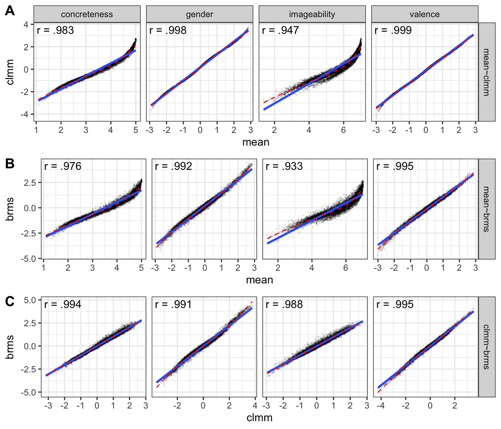

```r
czlex_summary_clmm_brms_comparison1 <- czlex_summary_clmm_brms_comparison %>%
  filter(comparison == "mean~clmm") %>%
  ggplot(aes(x = x, y = y)) +
  geom_point(size = 0.1, alpha = 0.1) +
  geom_smooth(method = "lm") +
  geom_smooth(method = "loess", colour = "red", size = 0.5, linetype = 2) +
  geom_label(data = czlex_summary_clmm_brms_comparison_cor %>%
              filter(comparison == "mean~clmm"),
            aes(x = -Inf, y = Inf, label = cor1),
            hjust = 0, vjust = 1, border.colour = "white", fill = alpha(c("white"), 0)) +
  xlab("mean") +
  ylab("clmm") +
  facet_grid(comparison~dimension, scales = "free") +
  theme_bw()

czlex_summary_clmm_brms_comparison2 <- czlex_summary_clmm_brms_comparison %>%
  filter(comparison == "mean~brms") %>%
  ggplot(aes(x = x, y = y)) +
  geom_point(size = 0.1, alpha = 0.1) +
  geom_smooth(method = "lm") +
  geom_smooth(method = "loess", colour = "red", size = 0.5, linetype = 2) +
  geom_label(data = czlex_summary_clmm_brms_comparison_cor %>%
              filter(comparison == "mean~brms"),
            aes(x = -Inf, y = Inf, label = cor1),
            hjust = 0, vjust = 1, border.colour = "white", fill = alpha(c("white"), 0)) +
  xlab("mean") +
  ylab("brms") +
  facet_grid(comparison~dimension, scales = "free") +
  theme_bw() +
  theme(strip.text.x = element_blank(),
        strip.background.x = element_blank())

czlex_summary_clmm_brms_comparison3 <- czlex_summary_clmm_brms_comparison %>%
  filter(comparison == "clmm~brms") %>%
  ggplot(aes(x = x, y = y)) +
  geom_point(size = 0.1, alpha = 0.1) +
  geom_smooth(method = "lm") +
  geom_smooth(method = "loess", colour = "red", size = 0.5, linetype = 2) +
  geom_label(data = czlex_summary_clmm_brms_comparison_cor %>%
              filter(comparison == "clmm~brms"),
            aes(x = -Inf, y = Inf, label = cor1),
            hjust = 0, vjust = 1, border.colour = "white", fill = alpha(c("white"), 0)) +
  xlab("clmm") +
  ylab("brms") +
  facet_grid(comparison~dimension, scales = "free") +
  theme_bw() +
  theme(strip.text.x = element_blank(),
        strip.background.x = element_blank())

czlex_summary_clmm_brms_comparison_plot <- plot_grid(czlex_summary_clmm_brms_comparison1,
          czlex_summary_clmm_brms_comparison2,
          czlex_summary_clmm_brms_comparison3,
          labels = c("A", "B", "C"),
          nrow = 3, ncol = 1, rel_heights = c(1, 0.9, 0.9))
czlex_summary_clmm_brms_comparison_plot
```

```r
ggsave(plot = czlex_summary_clmm_brms_comparison_plot, filename = "plots/summary_data_comparison.png", width = 7, height = 6, dpi = 400)
```

Item level variance

```r
czlex_summary_clmm_brms_comparison_sd <- czlex_summary_clmm_brms %>%
  select(name, starts_with("brms_")) %>%
  pivot_longer(-name, names_to = "dimension", values_to = "item estimate") %>%
  mutate(dimension = str_remove(dimension, "brms_")) %>%
  left_join(czlex_summary_clmm_brms %>%
              select(name, starts_with("sd_")) %>%
              pivot_longer(-name, names_to = "dimension", values_to = "sd") %>%
              mutate(dimension = str_remove(dimension, "sd_"))) %>%
  rename(x = `item estimate`,
         y = sd) %>%
  mutate(comparison = "brms~variance",
         estimate = "brms",
         variance = "SD") %>%
  bind_rows(czlex_summary_clmm_brms %>%
              select(name, starts_with("brms_")) %>%
              pivot_longer(-name, names_to = "dimension", values_to = "item estimate") %>%
              mutate(dimension = str_remove(dimension, "brms_")) %>%
              left_join(czlex_summary_clmm_brms %>%
                          select(name, starts_with("latent_sd")) %>%
                          pivot_longer(-name, names_to = "dimension", values_to = "latent_sd") %>%
                          mutate(dimension = str_remove(dimension, "latent_sd_"))) %>%
              rename(x = `item estimate`,
                     y = latent_sd) %>%
              mutate(comparison = "brms~variance",
                     estimate = "brms",
                     variance = "Latent SD")) %>%
  bind_rows(czlex_summary_clmm_brms %>%
              select(name, starts_with("mean_")) %>%
              pivot_longer(-name, names_to = "dimension", values_to = "item estimate") %>%
              mutate(dimension = str_remove(dimension, "mean_")) %>%
              left_join(czlex_summary_clmm_brms %>%
                          select(name, starts_with("sd_")) %>%
                          pivot_longer(-name, names_to = "dimension", values_to = "sd") %>%
                          mutate(dimension = str_remove(dimension, "sd_"))) %>%
              rename(x = `item estimate`,
                     y = sd) %>%
              mutate(comparison = "mean~variance",
                     estimate = "mean",
                     variance = "SD")) %>%
  bind_rows(czlex_summary_clmm_brms %>%
              select(name, starts_with("mean_")) %>%
              pivot_longer(-name, names_to = "dimension", values_to = "item estimate") %>%
              mutate(dimension = str_remove(dimension, "mean_")) %>%
              left_join(czlex_summary_clmm_brms %>%
                          select(name, starts_with("latent_sd")) %>%
                          pivot_longer(-name, names_to = "dimension", values_to = "latent_sd") %>%
                          mutate(dimension = str_remove(dimension, "latent_sd_"))) %>%
              rename(x = `item estimate`,
                     y = latent_sd) %>%
              mutate(comparison = "mean~variance",
                     estimate = "mean",
                     variance = "Latent SD")) %>%
  bind_rows(czlex_summary_clmm_brms %>%
              select(name, starts_with("sd_")) %>%
              pivot_longer(-name, names_to = "dimension", values_to = "sd") %>%
              mutate(dimension = str_remove(dimension, "sd_")) %>%
              left_join(czlex_summary_clmm_brms %>%
                          select(name, starts_with("latent_sd")) %>%
                          pivot_longer(-name, names_to = "dimension", values_to = "latent_sd") %>%
                          mutate(dimension = str_remove(dimension, "latent_sd_"))) %>%
              rename(x = sd,
                     y = latent_sd) %>%
              mutate(comparison = "SD~latent SD")) %>%
  mutate(comparison = factor(comparison, ordered = TRUE, levels = c("mean~variance", "brms~variance", "SD~latent SD"))) %>%
  filter(dimension != "aoa")
czlex_summary_clmm_brms_comparison_cor_sd <- czlex_summary_clmm_brms_comparison_sd %>%
  group_by(dimension, comparison) %>%
  summarise(cor = cor(x, y, use = "pairwise")) %>%
  ungroup() %>%
  mutate(cor1 = paste0("r = ", format(round(cor, 3), nsmall = 3)),
         cor1 = str_replace(cor1, "0.", "."))
```

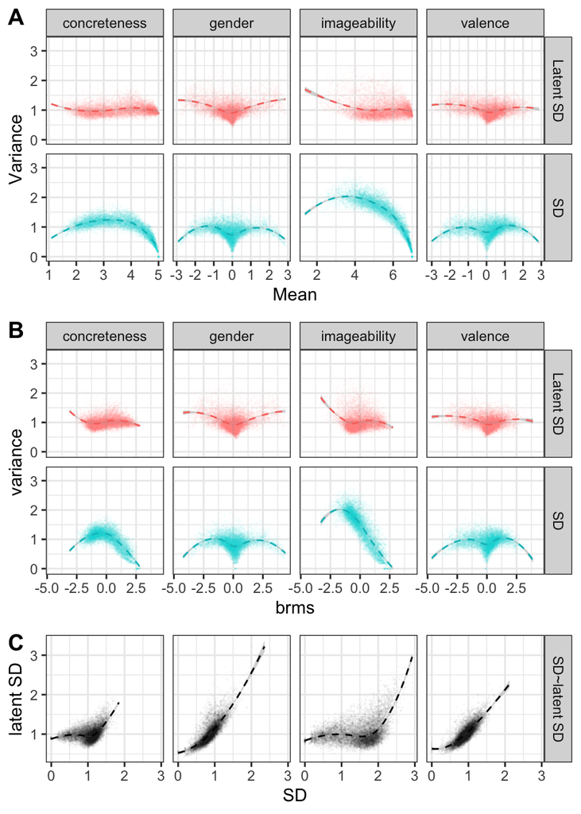

```r
czlex_summary_sd_comparison1 <- czlex_summary_clmm_brms_comparison_sd %>%
  filter(comparison == "mean~variance") %>%
  ggplot(aes(x = x, y = y, colour = variance)) +
  geom_point(size = 0.02, alpha = 0.02) +
  # geom_smooth(method = "lm") +
  geom_smooth(method = "loess", size = 0.5, linetype = 2) +
  # geom_label(data = czlex_summary_clmm_brms_comparison_cor_sd %>%
  #             filter(comparison == "mean~sd"),
  #           aes(x = -Inf, y = Inf, label = cor1),
  #           hjust = 0, vjust = 1, border.colour = "white", fill = alpha(c("white"), 0)) +
  xlab("Mean") +
  ylab("Variance") +
  facet_grid(variance~dimension, scales = "free_x") +
  theme_bw() +
  theme(legend.position = "none")

czlex_summary_sd_comparison2 <- czlex_summary_clmm_brms_comparison_sd %>%
  filter(comparison == "brms~variance") %>%
  ggplot(aes(x = x, y = y, colour = variance)) +
  geom_point(size = 0.02, alpha = 0.02) +
  # geom_smooth(method = "lm") +
  geom_smooth(method = "loess", size = 0.5, linetype = 2) +
  # geom_label(data = czlex_summary_clmm_brms_comparison_cor_sd %>%
  #             filter(comparison == "mean~sd"),
  #           aes(x = -Inf, y = Inf, label = cor1),
  #           hjust = 0, vjust = 1, border.colour = "white", fill = alpha(c("white"), 0)) +
  xlab("brms") +
  ylab("variance") +
  facet_grid(variance~dimension) +
  theme_bw() +
  theme(legend.position = "none")

czlex_summary_sd_comparison3 <- czlex_summary_clmm_brms_comparison_sd %>%
  filter(comparison == "SD~latent SD") %>%
  ggplot(aes(x = x, y = y)) +
  geom_point(size = 0.02, alpha = 0.02) +
  # geom_smooth(method = "lm") +
  geom_smooth(method = "loess", colour = "black", size = 0.5, linetype = 2) +
  # geom_label(data = czlex_summary_clmm_brms_comparison_cor_sd %>%
  #             filter(comparison == "sd~latent_sd"),
  #           aes(x = -Inf, y = Inf, label = cor1),
  #           hjust = 0, vjust = 1, border.colour = "white", fill = alpha(c("white"), 0)) +
  xlab("SD") +
  ylab("latent SD") +
  facet_grid(comparison~dimension) +
  theme_bw() +
  theme(strip.text.x = element_blank(),
        strip.background.x = element_blank())

czlex_summary_sd_comparison_plot <- plot_grid(czlex_summary_sd_comparison1,
          czlex_summary_sd_comparison2,
          czlex_summary_sd_comparison3,
          labels = c("A", "B", "C"),
          nrow = 3, ncol = 1, rel_heights = c(1, 1, 0.6))
czlex_summary_sd_comparison_plot
```

```r
ggsave(plot = czlex_summary_sd_comparison_plot, filename = "plots/sd_data_comparison.png", width = 5, height = 7, dpi = 400)
```

## Correlations

```r
cor_data <- czlex_summary_clmm_brms %>%
  select(name, starts_with("mean_")) %>%
  left_join(czlex_word_list_variables %>%
              select(-frequency))
```

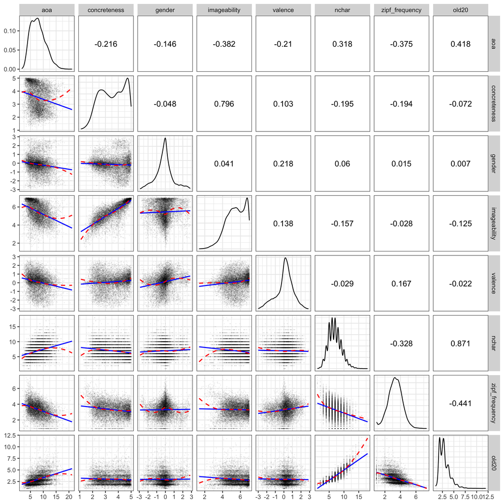

```r
scatter_reg_curve <- function(data, mapping, ...) {
  ggplot(data = data, mapping = mapping) +
    geom_point(size = 0.05, alpha = 0.05) +
    geom_smooth(method = "lm", colour = "blue", se = FALSE, size = 0.7) + # Add regression curve
    geom_smooth(method = "loess", colour = "red", se = FALSE, size = 0.7, linetype = 2) + # Add regression curve
    theme_bw()
}

cor_func <- function(data, mapping, method, ...){
  x <- eval_data_col(data, mapping$x)
  y <- eval_data_col(data, mapping$y)

  corr <- cor(x, y, method=method, use='complete.obs')

  ggally_text(
    label = as.character(round(corr, 3)),
    mapping = aes(),
    xP = 0.5, yP = 0.5,
    color = 'black',
    ...
  ) +
    theme_bw(base_line_size = 0)
}

# Creating the correlation matrix plot
plot_matrix <- ggpairs(
  cor_data %>%
    select(-name) %>%
    rename_with(~str_remove(.x, "mean_")),
  lower = list(
    continuous = wrap(scatter_reg_curve)
  ),
  diag = list(continuous = function(data, mapping, ...) {
                  ggally_densityDiag(data = data, mapping = mapping) +
                  theme_bw()}),
  upper = list(continuous = wrap(cor_func, method = "pearson", size = 4, stars = FALSE)),
  )

# Display the plot
plot_matrix
```

```r
ggsave(plot_matrix, filename = "plots/correlation_plot_matrix.png", height = 10, width = 10, dpi = 400)
```

## Modelling of lexical decision data

```r
czlex_summary_ldt <- czlex_summary_clmm_brms %>%
  left_join(czlex_word_list_variables) %>%
  left_join(czlex_ldt) %>%
  drop_na()
rt_baseline0 <- czlex_summary_ldt %>%
  lm(rt_intercept ~ zipf_frequency + old20 + nchar, data = .)

rt_baseline0 %>%
  summary()
```

```
##
## Call:
## lm(formula = rt_intercept ~ zipf_frequency + old20 + nchar, data = .)
##
## Residuals:
##     Min      1Q  Median      3Q     Max
## -353.16  -80.70  -19.92   52.90 1356.80
##
## Coefficients:
##                Estimate Std. Error t value Pr(>|t|)
## (Intercept)      54.128      8.517   6.356 2.18e-10 ***
## zipf_frequency  -86.961      1.709 -50.870  < 2e-16 ***
## old20            70.082      2.673  26.216  < 2e-16 ***
## nchar           -15.880      1.327 -11.963  < 2e-16 ***
## ---
## Signif. codes:  0 '***' 0.001 '**' 0.01 '*' 0.05 '.' 0.1 ' ' 1
##
## Residual standard error: 132 on 9239 degrees of freedom
## Multiple R-squared:  0.4196, Adjusted R-squared:  0.4194
## F-statistic:  2227 on 3 and 9239 DF,  p-value: < 2.2e-16
```

```r
ols_vif_tol(rt_baseline0)
```

| Variables | Tolerance | VIF |
| --- | --- | --- |
| zipf_frequency | 0.7907479 | 1.264626 |
| old20 | 0.2041125 | 4.899259 |
| nchar | 0.2252138 | 4.440226 |

Step 1 baseline

```r
rt_baseline1 <- czlex_summary_ldt %>%
  lm(rt_intercept ~ zipf_frequency + old20, data = .)

rt_baseline1 %>%
  summary()
```

```
##
## Call:
## lm(formula = rt_intercept ~ zipf_frequency + old20, data = .)
##
## Residuals:
##     Min      1Q  Median      3Q     Max
## -379.52  -80.30  -20.45   49.71 1370.48
##
## Coefficients:
##                Estimate Std. Error t value Pr(>|t|)
## (Intercept)      33.722      8.408   4.011  6.1e-05 ***
## zipf_frequency  -89.441      1.710 -52.308  < 2e-16 ***
## old20            42.466      1.358  31.259  < 2e-16 ***
## ---
## Signif. codes:  0 '***' 0.001 '**' 0.01 '*' 0.05 '.' 0.1 ' ' 1
##
## Residual standard error: 133 on 9240 degrees of freedom
## Multiple R-squared:  0.4106, Adjusted R-squared:  0.4105
## F-statistic:  3219 on 2 and 9240 DF,  p-value: < 2.2e-16
```

```r
ols_vif_tol(rt_baseline1)
```

| Variables | Tolerance | VIF |
| --- | --- | --- |
| zipf_frequency | 0.8025429 | 1.246039 |
| old20 | 0.8025429 | 1.246039 |

Step 2 psycholinguistic

```r
rt_model_mean <- czlex_summary_ldt %>%
  select(rt_intercept, zipf_frequency, old20, mean_aoa, mean_imageability, mean_gender, mean_valence) %>%
  mutate(valence_abs = abs(mean_valence),
         gender_abs = abs(mean_gender)) %>%
  rename(aoa = mean_aoa,
         imageability = mean_imageability,
         gender = mean_gender,
         valence = valence_abs) %>%
  lm(rt_intercept ~ zipf_frequency + old20 + aoa + imageability + gender + valence, data = .)

anova(rt_baseline1, rt_model_mean)
```

|  | Res.Df | RSS | Df | Sum of Sq | F | Pr(>F) |
| --- | --- | --- | --- | --- | --- | --- |
| 1 | 9240 | 163392183 | NA | NA | NA | NA |
| 2 | 9236 | 127272765 | 4 | 36119419 | 655.2835 | 0 |

```r
rt_model_mean %>%
  summary()
```

```
##
## Call:
## lm(formula = rt_intercept ~ zipf_frequency + old20 + aoa + imageability +
##     gender + valence, data = .)
##
## Residuals:
##     Min      1Q  Median      3Q     Max
## -418.10  -70.67  -14.28   48.70 1248.03
##
## Coefficients:
##                Estimate Std. Error t value Pr(>|t|)
## (Intercept)    215.9832    13.5988  15.883  < 2e-16 ***
## zipf_frequency -88.3965     1.6018 -55.184  < 2e-16 ***
## old20           25.4367     1.2708  20.017  < 2e-16 ***
## aoa             12.1859     0.5474  22.261  < 2e-16 ***
## imageability   -40.0831     1.3389 -29.938  < 2e-16 ***
## gender          -5.1215     1.3570  -3.774 0.000162 ***
## valence        -18.2213     1.9905  -9.154  < 2e-16 ***
## ---
## Signif. codes:  0 '***' 0.001 '**' 0.01 '*' 0.05 '.' 0.1 ' ' 1
##
## Residual standard error: 117.4 on 9236 degrees of freedom
## Multiple R-squared:  0.5409, Adjusted R-squared:  0.5406
## F-statistic:  1814 on 6 and 9236 DF,  p-value: < 2.2e-16
```

```r
ols_vif_tol(rt_model_mean)
```

| Variables | Tolerance | VIF |
| --- | --- | --- |
| zipf_frequency | 0.7126142 | 1.403284 |
| old20 | 0.7147117 | 1.399166 |
| aoa | 0.6155554 | 1.624549 |
| imageability | 0.7926967 | 1.261517 |
| gender | 0.9686140 | 1.032403 |
| valence | 0.9884884 | 1.011646 |

```r
error_baseline0 <- czlex_summary_ldt %>%
  lm(acc_intercept ~ zipf_frequency + old20 + nchar, data = .)

error_baseline0 %>%
  summary()
```

```
##
## Call:
## lm(formula = acc_intercept ~ zipf_frequency + old20 + nchar,
##     data = .)
##
## Residuals:
##     Min      1Q  Median      3Q     Max
## -5.3196 -0.6301  0.1473  0.8035  3.1527
##
## Coefficients:
##                Estimate Std. Error t value Pr(>|t|)
## (Intercept)    -2.39722    0.07366  -32.54   <2e-16 ***
## zipf_frequency  0.62723    0.01479   42.42   <2e-16 ***
## old20          -0.56510    0.02312  -24.44   <2e-16 ***
## nchar           0.35186    0.01148   30.65   <2e-16 ***
## ---
## Signif. codes:  0 '***' 0.001 '**' 0.01 '*' 0.05 '.' 0.1 ' ' 1
##
## Residual standard error: 1.141 on 9239 degrees of freedom
## Multiple R-squared:  0.2716, Adjusted R-squared:  0.2713
## F-statistic:  1148 on 3 and 9239 DF,  p-value: < 2.2e-16
```

```r
ols_vif_tol(error_baseline0)
```

| Variables | Tolerance | VIF |
| --- | --- | --- |
| zipf_frequency | 0.7907479 | 1.264626 |
| old20 | 0.2041125 | 4.899259 |
| nchar | 0.2252138 | 4.440226 |

```r
acc_baseline1 <- czlex_summary_ldt %>%
  lm(acc_intercept ~ zipf_frequency + old20, data = .)

acc_baseline1 %>%
  summary()
```

```
##
## Call:
## lm(formula = acc_intercept ~ zipf_frequency + old20, data = .)
##
## Residuals:
##     Min      1Q  Median      3Q     Max
## -6.0205 -0.5889  0.1980  0.8539  2.8528
##
## Coefficients:
##                Estimate Std. Error t value Pr(>|t|)
## (Intercept)    -1.94509    0.07575 -25.679  < 2e-16 ***
## zipf_frequency  0.68216    0.01540  44.284  < 2e-16 ***
## old20           0.04680    0.01224   3.824 0.000132 ***
## ---
## Signif. codes:  0 '***' 0.001 '**' 0.01 '*' 0.05 '.' 0.1 ' ' 1
##
## Residual standard error: 1.198 on 9240 degrees of freedom
## Multiple R-squared:  0.1975, Adjusted R-squared:  0.1973
## F-statistic:  1137 on 2 and 9240 DF,  p-value: < 2.2e-16
```

```r
acc_model_mean <- czlex_summary_ldt %>%
  select(acc_intercept, zipf_frequency, old20, mean_aoa, mean_imageability, mean_gender, mean_valence) %>%
  mutate(valence_abs = abs(mean_valence),
         gender_abs = abs(mean_gender)) %>%
  rename(aoa = mean_aoa,
         imageability = mean_imageability,
         gender = mean_gender,
         valence = valence_abs) %>%
  lm(acc_intercept ~ zipf_frequency + old20 + aoa + imageability + gender + valence, data = .)

anova(acc_baseline1, acc_model_mean)
```

|  | Res.Df | RSS | Df | Sum of Sq | F | Pr(>F) |
| --- | --- | --- | --- | --- | --- | --- |
| 1 | 9240 | 13261.23 | NA | NA | NA | NA |
| 2 | 9236 | 10224.50 | 4 | 3036.732 | 685.7856 | 0 |

```r
acc_model_mean %>%
  summary()
```

```
##
## Call:
## lm(formula = acc_intercept ~ zipf_frequency + old20 + aoa + imageability +
##     gender + valence, data = .)
##
## Residuals:
##     Min      1Q  Median      3Q     Max
## -4.6968 -0.6292  0.1099  0.7406  3.5179
##
## Coefficients:
##                 Estimate Std. Error t value Pr(>|t|)
## (Intercept)    -1.339168   0.121886 -10.987  < 2e-16 ***
## zipf_frequency  0.571425   0.014357  39.800  < 2e-16 ***
## old20           0.223702   0.011390  19.640  < 2e-16 ***
## aoa            -0.191155   0.004906 -38.961  < 2e-16 ***
## imageability    0.109020   0.012000   9.085  < 2e-16 ***
## gender          0.056478   0.012163   4.643 3.47e-06 ***
## valence         0.226866   0.017841  12.716  < 2e-16 ***
## ---
## Signif. codes:  0 '***' 0.001 '**' 0.01 '*' 0.05 '.' 0.1 ' ' 1
##
## Residual standard error: 1.052 on 9236 degrees of freedom
## Multiple R-squared:  0.3813, Adjusted R-squared:  0.3809
## F-statistic: 948.6 on 6 and 9236 DF,  p-value: < 2.2e-16
```

```r
rt_model_clmm <- czlex_summary_ldt %>%
  select(rt_intercept, zipf_frequency, old20, mean_aoa, clmm_imageability, clmm_gender, clmm_valence) %>%
  mutate(valence_abs = abs(clmm_valence),
         gender_abs = abs(clmm_gender)) %>%
  rename(aoa = mean_aoa,
         imageability = clmm_imageability,
         gender = clmm_gender,
         valence = valence_abs) %>%
  lm(rt_intercept ~ zipf_frequency + old20 + aoa + imageability + gender + valence, data = .)

anova(rt_baseline1, rt_model_clmm)
```

|  | Res.Df | RSS | Df | Sum of Sq | F | Pr(>F) |
| --- | --- | --- | --- | --- | --- | --- |
| 1 | 9240 | 163392183 | NA | NA | NA | NA |
| 2 | 9236 | 129323318 | 4 | 34068866 | 608.2817 | 0 |

```r
rt_model_clmm %>%
  summary()
```

```
##
## Call:
## lm(formula = rt_intercept ~ zipf_frequency + old20 + aoa + imageability +
##     gender + valence, data = .)
##
## Residuals:
##     Min      1Q  Median      3Q     Max
## -405.21  -70.88  -14.03   49.19 1269.34
##
## Coefficients:
##                Estimate Std. Error t value Pr(>|t|)
## (Intercept)      0.7314     9.4220   0.078    0.938
## zipf_frequency -88.2063     1.6213 -54.406  < 2e-16 ***
## old20           25.1449     1.2805  19.636  < 2e-16 ***
## aoa             12.1692     0.5620  21.652  < 2e-16 ***
## imageability   -40.0944     1.4608 -27.447  < 2e-16 ***
## gender          -4.9897     1.1769  -4.240 2.26e-05 ***
## valence        -19.2115     1.7917 -10.723  < 2e-16 ***
## ---
## Signif. codes:  0 '***' 0.001 '**' 0.01 '*' 0.05 '.' 0.1 ' ' 1
##
## Residual standard error: 118.3 on 9236 degrees of freedom
## Multiple R-squared:  0.5335, Adjusted R-squared:  0.5332
## F-statistic:  1761 on 6 and 9236 DF,  p-value: < 2.2e-16
```

```r
acc_model_clmm <- czlex_summary_ldt %>%
  select(acc_intercept, zipf_frequency, old20, mean_aoa, clmm_imageability, clmm_gender, clmm_valence) %>%
  mutate(valence_abs = abs(clmm_valence),
         gender_abs = abs(clmm_gender)) %>%
  rename(aoa = mean_aoa,
         imageability = clmm_imageability,
         gender = clmm_gender,
         valence = valence_abs) %>%
  lm(acc_intercept ~ zipf_frequency + old20 + aoa + imageability + gender + valence, data = .)

anova(acc_baseline1, acc_model_clmm)
```

|  | Res.Df | RSS | Df | Sum of Sq | F | Pr(>F) |
| --- | --- | --- | --- | --- | --- | --- |
| 1 | 9240 | 13261.23 | NA | NA | NA | NA |
| 2 | 9236 | 10240.15 | 4 | 3021.084 | 681.2092 | 0 |

```r
acc_model_clmm %>%
  summary()
```

```
##
## Call:
## lm(formula = acc_intercept ~ zipf_frequency + old20 + aoa + imageability +
##     gender + valence, data = .)
##
## Residuals:
##     Min      1Q  Median      3Q     Max
## -4.6977 -0.6304  0.1141  0.7417  3.4343
##
## Coefficients:
##                 Estimate Std. Error t value Pr(>|t|)
## (Intercept)    -0.736128   0.083841  -8.780  < 2e-16 ***
## zipf_frequency  0.568994   0.014427  39.441  < 2e-16 ***
## old20           0.225523   0.011395  19.792  < 2e-16 ***
## aoa            -0.194866   0.005001 -38.963  < 2e-16 ***
## imageability    0.092757   0.012999   7.136 1.04e-12 ***
## gender          0.049882   0.010473   4.763 1.94e-06 ***
## valence         0.225389   0.015943  14.137  < 2e-16 ***
## ---
## Signif. codes:  0 '***' 0.001 '**' 0.01 '*' 0.05 '.' 0.1 ' ' 1
##
## Residual standard error: 1.053 on 9236 degrees of freedom
## Multiple R-squared:  0.3803, Adjusted R-squared:  0.3799
## F-statistic: 944.8 on 6 and 9236 DF,  p-value: < 2.2e-16
```

```r
rt_model_brms <- czlex_summary_ldt %>%
  select(rt_intercept, zipf_frequency, old20, mean_aoa, brms_imageability, brms_gender, brms_valence) %>%
  mutate(valence_abs = abs(brms_valence),
         gender_abs = abs(brms_gender)) %>%
  rename(aoa = mean_aoa,
         imageability = brms_imageability,
         gender = brms_gender,
         valence = valence_abs) %>%
  lm(rt_intercept ~ zipf_frequency + old20 + aoa + imageability + gender + valence, data = .)

anova(rt_baseline1, rt_model_brms)
```

|  | Res.Df | RSS | Df | Sum of Sq | F | Pr(>F) |
| --- | --- | --- | --- | --- | --- | --- |
| 1 | 9240 | 163392183 | NA | NA | NA | NA |
| 2 | 9236 | 130930658 | 4 | 32461526 | 572.4684 | 0 |

```r
rt_model_brms %>%
  summary()
```

```
##
## Call:
## lm(formula = rt_intercept ~ zipf_frequency + old20 + aoa + imageability +
##     gender + valence, data = .)
##
## Residuals:
##     Min      1Q  Median      3Q     Max
## -409.95  -71.04  -14.37   48.77 1277.82
##
## Coefficients:
##                Estimate Std. Error t value Pr(>|t|)
## (Intercept)     -9.1069     9.4488  -0.964    0.335
## zipf_frequency -88.0338     1.6393 -53.701  < 2e-16 ***
## old20           24.8377     1.2896  19.261  < 2e-16 ***
## aoa             13.3595     0.5543  24.100  < 2e-16 ***
## imageability   -36.6861     1.4549 -25.216  < 2e-16 ***
## gender          -4.5041     1.0689  -4.214 2.54e-05 ***
## valence        -17.9604     1.6407 -10.947  < 2e-16 ***
## ---
## Signif. codes:  0 '***' 0.001 '**' 0.01 '*' 0.05 '.' 0.1 ' ' 1
##
## Residual standard error: 119.1 on 9236 degrees of freedom
## Multiple R-squared:  0.5277, Adjusted R-squared:  0.5274
## F-statistic:  1720 on 6 and 9236 DF,  p-value: < 2.2e-16
```

```r
acc_model_brms <- czlex_summary_ldt %>%
  select(acc_intercept, zipf_frequency, old20, mean_aoa, brms_imageability, brms_gender, brms_valence) %>%
  mutate(valence_abs = abs(brms_valence),
         gender_abs = abs(brms_gender)) %>%
  rename(aoa = mean_aoa,
         imageability = brms_imageability,
         gender = brms_gender,
         valence = valence_abs) %>%
  lm(acc_intercept ~ zipf_frequency + old20 + aoa + imageability + gender + valence, data = .)

anova(acc_baseline1, acc_model_brms)
```

|  | Res.Df | RSS | Df | Sum of Sq | F | Pr(>F) |
| --- | --- | --- | --- | --- | --- | --- |
| 1 | 9240 | 13261.23 | NA | NA | NA | NA |
| 2 | 9236 | 10270.54 | 4 | 2990.689 | 672.3601 | 0 |

```r
acc_model_brms %>%
  summary()
```

```
##
## Call:
## lm(formula = acc_intercept ~ zipf_frequency + old20 + aoa + imageability +
##     gender + valence, data = .)
##
## Residuals:
##     Min      1Q  Median      3Q     Max
## -4.7519 -0.6285  0.1102  0.7418  3.3906
##
## Coefficients:
##                 Estimate Std. Error t value Pr(>|t|)
## (Intercept)    -0.637195   0.083686  -7.614 2.92e-14 ***
## zipf_frequency  0.560267   0.014519  38.588  < 2e-16 ***
## old20           0.224621   0.011421  19.667  < 2e-16 ***
## aoa            -0.202110   0.004910 -41.166  < 2e-16 ***
## imageability    0.057988   0.012886   4.500 6.87e-06 ***
## gender          0.045884   0.009467   4.847 1.28e-06 ***
## valence         0.204866   0.014531  14.098  < 2e-16 ***
## ---
## Signif. codes:  0 '***' 0.001 '**' 0.01 '*' 0.05 '.' 0.1 ' ' 1
##
## Residual standard error: 1.055 on 9236 degrees of freedom
## Multiple R-squared:  0.3785, Adjusted R-squared:  0.3781
## F-statistic: 937.4 on 6 and 9236 DF,  p-value: < 2.2e-16
```

```r
ols_vif_tol(rt_model_clmm)
```

| Variables | Tolerance | VIF |
| --- | --- | --- |
| zipf_frequency | 0.7068669 | 1.414693 |
| old20 | 0.7152128 | 1.398185 |
| aoa | 0.5933145 | 1.685447 |
| imageability | 0.7610076 | 1.314047 |
| gender | 0.9685117 | 1.032512 |
| valence | 0.9891057 | 1.011014 |

```r
ols_vif_tol(rt_model_brms)
```

| Variables | Tolerance | VIF |
| --- | --- | --- |
| zipf_frequency | 0.6999500 | 1.428673 |
| old20 | 0.7140001 | 1.400560 |
| aoa | 0.6174928 | 1.619452 |
| imageability | 0.7843532 | 1.274936 |
| gender | 0.9693984 | 1.031568 |
| valence | 0.9854880 | 1.014726 |

```r
ols_vif_tol(acc_model_clmm)
```

| Variables | Tolerance | VIF |
| --- | --- | --- |
| zipf_frequency | 0.7068669 | 1.414693 |
| old20 | 0.7152128 | 1.398185 |
| aoa | 0.5933145 | 1.685447 |
| imageability | 0.7610076 | 1.314047 |
| gender | 0.9685117 | 1.032512 |
| valence | 0.9891057 | 1.011014 |

```r
ols_vif_tol(acc_model_brms)
```

| Variables | Tolerance | VIF |
| --- | --- | --- |
| zipf_frequency | 0.6999500 | 1.428673 |
| old20 | 0.7140001 | 1.400560 |
| aoa | 0.6174928 | 1.619452 |
| imageability | 0.7843532 | 1.274936 |
| gender | 0.9693984 | 1.031568 |
| valence | 0.9854880 | 1.014726 |

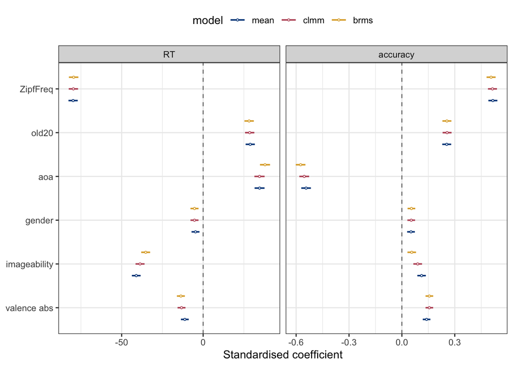

```r
coeffs_full <- summ(rt_model_mean, confint = TRUE, scale = TRUE)$coeftable %>%
  as.data.frame() %>%
  rownames_to_column("predictor") %>%
  mutate(model = "mean",
         predicted = "RT") %>%
  bind_rows(summ(rt_model_clmm, confint = TRUE, scale = TRUE)$coeftable %>%
              as.data.frame() %>%
              rownames_to_column("predictor") %>%
              mutate(model = "clmm",
                     predicted = "RT")) %>%
  bind_rows(summ(rt_model_brms, confint = TRUE, scale = TRUE)$coeftable %>%
              as.data.frame() %>%
              rownames_to_column("predictor") %>%
              mutate(model = "brms",
                     predicted = "RT")) %>%
  bind_rows(summ(acc_model_mean, confint = TRUE, scale = TRUE)$coeftable %>%
              as.data.frame() %>%
              rownames_to_column("predictor") %>%
              mutate(model = "mean",
                     predicted = "accuracy")) %>%
  bind_rows(summ(acc_model_clmm, confint = TRUE, scale = TRUE)$coeftable %>%
              as.data.frame() %>%
              rownames_to_column("predictor") %>%
              mutate(model = "clmm",
                     predicted = "accuracy")) %>%
  bind_rows(summ(acc_model_brms, confint = TRUE, scale = TRUE)$coeftable %>%
              as.data.frame() %>%
              rownames_to_column("predictor") %>%
              mutate(model = "brms",
                     predicted = "accuracy")) %>%
  rename(`Standardised coefficient` = 2,
         lower = `2.5%`,
         upper = `97.5%`) %>%
  mutate(predictor = ifelse(predictor == "zipf_frequency", "ZipfFreq",
                ifelse(predictor == "valence", "valence abs",
                       ifelse(predictor == "gender", "gender", predictor))),
         predictor = factor(predictor, ordered = TRUE, levels = c("valence abs", "imageability", "gender", "aoa", "old20", "ZipfFreq")),
         model = factor(model, ordered = TRUE, levels = c("mean", "clmm", "brms")),
         predicted = factor(predicted, ordered = TRUE, levels = c("RT", "accuracy")))

coeffs_full_plot <- coeffs_full %>%
  filter(predictor != "(Intercept)") %>%
  ggplot(aes(x = `Standardised coefficient`, y = predictor, colour = model)) +
  geom_linerange(aes(xmin = lower, xmax = upper), size = 0.7, position = position_dodge(0.8)) +
  geom_point(size = 0.7, shape = 21, fill = "white", position = position_dodge(0.8)) +
  geom_vline(xintercept = 0, linetype = 2, linewidth = .25) +
  scale_color_manual(values = c("#004488", "#BB5566", "#DDAA33")) +
  facet_grid(~predicted, scales = "free") +
  theme_bw() +
  theme(legend.position = "top",
        axis.title.y = element_blank())

coeffs_full_plot
```

```r
ggsave(plot = coeffs_full_plot, "plots/coeffs_full_plot.png", height = 4, width = 8, dpi = 400)
```

```r
czlex_summary_ldt <- czlex_summary_ldt %>%
  mutate(valence_abs_mean = abs(mean_valence),
         gender_abs_mean = abs(mean_gender),
         valence_abs_clmm = abs(clmm_valence),
         gender_abs_clmm = abs(clmm_gender),
         valence_abs_brms = abs(brms_valence),
         gender_abs_brms = abs(brms_gender))

rt_baseline1 <- czlex_summary_ldt %>%
  lm(rt_intercept ~ zipf_frequency + old20, data = .)

rt_concreteness_models <- list(
  mean_concreteness = czlex_summary_ldt %>%
    lm(rt_intercept ~ zipf_frequency + old20 + mean_concreteness, data = .),
  clmm_concreteness = czlex_summary_ldt %>%
    lm(rt_intercept ~ zipf_frequency + old20 + clmm_concreteness, data = .),
  brms_concreteness = czlex_summary_ldt %>%
    lm(rt_intercept ~ zipf_frequency + old20 + brms_concreteness, data = .)
)

rt_concreteness_r2_tbl <- map_dfr(
  rt_concreteness_models,
  ~ summary(.x)$r.squared
  ) %>%
  pivot_longer(everything(), names_to = "predictor", values_to = "R2") %>%
  left_join(map_dfr(
    rt_concreteness_models,
    ~ summary(.x)$adj.r.squared
    ) %>%
  pivot_longer(everything(), names_to = "predictor", values_to = "R2 adj")) %>%
  mutate(
    baseline_R2 = summary(rt_baseline1)$adj.r.squared,
    delta_R2 = `R2 adj` - baseline_R2
  )
rt_gender_models <- list(
  mean_gender = czlex_summary_ldt %>%
    lm(rt_intercept ~ zipf_frequency + old20 + mean_gender, data = .),
  clmm_gender = czlex_summary_ldt %>%
    lm(rt_intercept ~ zipf_frequency + old20 + clmm_gender, data = .),
  brms_gender = czlex_summary_ldt %>%
    lm(rt_intercept ~ zipf_frequency + old20 + brms_gender, data = .)
)

rt_gender_r2_tbl <- map_dfr(
  rt_gender_models,
  ~ summary(.x)$r.squared
  ) %>%
  pivot_longer(everything(), names_to = "predictor", values_to = "R2") %>%
  left_join(map_dfr(
    rt_gender_models,
    ~ summary(.x)$adj.r.squared
    ) %>%
  pivot_longer(everything(), names_to = "predictor", values_to = "R2 adj")) %>%
  mutate(
    baseline_R2 = summary(rt_baseline1)$adj.r.squared,
    delta_R2 = `R2 adj` - baseline_R2
  )
rt_imageability_models <- list(
  mean_imageability = czlex_summary_ldt %>%
    lm(rt_intercept ~ zipf_frequency + old20 + mean_imageability, data = .),
  clmm_imageability = czlex_summary_ldt %>%
    lm(rt_intercept ~ zipf_frequency + old20 + clmm_imageability, data = .),
  brms_imageability = czlex_summary_ldt %>%
    lm(rt_intercept ~ zipf_frequency + old20 + brms_imageability, data = .)
)

rt_imageability_r2_tbl <- map_dfr(
  rt_imageability_models,
  ~ summary(.x)$r.squared
  ) %>%
  pivot_longer(everything(), names_to = "predictor", values_to = "R2") %>%
  left_join(map_dfr(
    rt_imageability_models,
    ~ summary(.x)$adj.r.squared
    ) %>%
  pivot_longer(everything(), names_to = "predictor", values_to = "R2 adj")) %>%
  mutate(
    baseline_R2 = summary(rt_baseline1)$adj.r.squared,
    delta_R2 = `R2 adj` - baseline_R2
  )
rt_valence_models <- list(
  mean_valence = czlex_summary_ldt %>%
    lm(rt_intercept ~ zipf_frequency + old20 + valence_abs_mean, data = .),
  clmm_valence = czlex_summary_ldt %>%
    lm(rt_intercept ~ zipf_frequency + old20 + valence_abs_clmm, data = .),
  brms_valence = czlex_summary_ldt %>%
    lm(rt_intercept ~ zipf_frequency + old20 + valence_abs_brms, data = .)
)

rt_valence_r2_tbl <- map_dfr(
  rt_valence_models,
  ~ summary(.x)$r.squared
  ) %>%
  pivot_longer(everything(), names_to = "predictor", values_to = "R2") %>%
  left_join(map_dfr(
    rt_valence_models,
    ~ summary(.x)$adj.r.squared
    ) %>%
  pivot_longer(everything(), names_to = "predictor", values_to = "R2 adj")) %>%
  mutate(
    baseline_R2 = summary(rt_baseline1)$adj.r.squared,
    delta_R2 = `R2 adj` - baseline_R2
  )
rt_r2_tbl <- rt_concreteness_r2_tbl %>%
  bind_rows(rt_gender_r2_tbl) %>%
  bind_rows(rt_imageability_r2_tbl) %>%
  bind_rows(rt_valence_r2_tbl)
```

```r
acc_baseline1 <- czlex_summary_ldt %>%
  lm(acc_intercept ~ zipf_frequency + old20, data = .)

acc_concreteness_models <- list(
  mean_concreteness = czlex_summary_ldt %>%
    lm(acc_intercept ~ zipf_frequency + old20 + mean_concreteness, data = .),
  clmm_concreteness = czlex_summary_ldt %>%
    lm(acc_intercept ~ zipf_frequency + old20 + clmm_concreteness, data = .),
  brms_concreteness = czlex_summary_ldt %>%
    lm(acc_intercept ~ zipf_frequency + old20 + brms_concreteness, data = .)
)

acc_concreteness_r2_tbl <- map_dfr(
  acc_concreteness_models,
  ~ summary(.x)$r.squared
  ) %>%
  pivot_longer(everything(), names_to = "predictor", values_to = "R2") %>%
  left_join(map_dfr(
    acc_concreteness_models,
    ~ summary(.x)$adj.r.squared
    ) %>%
  pivot_longer(everything(), names_to = "predictor", values_to = "R2 adj")) %>%
  mutate(
    baseline_R2 = summary(acc_baseline1)$adj.r.squared,
    delta_R2 = `R2 adj` - baseline_R2
  )
acc_gender_models <- list(
  mean_gender = czlex_summary_ldt %>%
    lm(acc_intercept ~ zipf_frequency + old20 + mean_gender, data = .),
  clmm_gender = czlex_summary_ldt %>%
    lm(acc_intercept ~ zipf_frequency + old20 + clmm_gender, data = .),
  brms_gender = czlex_summary_ldt %>%
    lm(acc_intercept ~ zipf_frequency + old20 + brms_gender, data = .)
)

acc_gender_r2_tbl <- map_dfr(
  acc_gender_models,
  ~ summary(.x)$r.squared
  ) %>%
  pivot_longer(everything(), names_to = "predictor", values_to = "R2") %>%
  left_join(map_dfr(
    acc_gender_models,
    ~ summary(.x)$adj.r.squared
    ) %>%
  pivot_longer(everything(), names_to = "predictor", values_to = "R2 adj")) %>%
  mutate(
    baseline_R2 = summary(acc_baseline1)$adj.r.squared,
    delta_R2 = `R2 adj` - baseline_R2
  )
acc_imageability_models <- list(
  mean_imageability = czlex_summary_ldt %>%
    lm(acc_intercept ~ zipf_frequency + old20 + mean_imageability, data = .),
  clmm_imageability = czlex_summary_ldt %>%
    lm(acc_intercept ~ zipf_frequency + old20 + clmm_imageability, data = .),
  brms_imageability = czlex_summary_ldt %>%
    lm(acc_intercept ~ zipf_frequency + old20 + brms_imageability, data = .)
)

acc_imageability_r2_tbl <- map_dfr(
  acc_imageability_models,
  ~ summary(.x)$r.squared
  ) %>%
  pivot_longer(everything(), names_to = "predictor", values_to = "R2") %>%
  left_join(map_dfr(
    acc_imageability_models,
    ~ summary(.x)$adj.r.squared
    ) %>%
  pivot_longer(everything(), names_to = "predictor", values_to = "R2 adj")) %>%
  mutate(
    baseline_R2 = summary(acc_baseline1)$adj.r.squared,
    delta_R2 = `R2 adj` - baseline_R2
  )
acc_valence_models <- list(
  mean_valence = czlex_summary_ldt %>%
    lm(acc_intercept ~ zipf_frequency + old20 + valence_abs_mean, data = .),
  clmm_valence = czlex_summary_ldt %>%
    lm(acc_intercept ~ zipf_frequency + old20 + valence_abs_clmm, data = .),
  brms_valence = czlex_summary_ldt %>%
    lm(acc_intercept ~ zipf_frequency + old20 + valence_abs_brms, data = .)
)

acc_valence_r2_tbl <- map_dfr(
  acc_valence_models,
  ~ summary(.x)$r.squared
  ) %>%
  pivot_longer(everything(), names_to = "predictor", values_to = "R2") %>%
  left_join(map_dfr(
    acc_valence_models,
    ~ summary(.x)$adj.r.squared
    ) %>%
  pivot_longer(everything(), names_to = "predictor", values_to = "R2 adj")) %>%
  mutate(
    baseline_R2 = summary(acc_baseline1)$adj.r.squared,
    delta_R2 = `R2 adj` - baseline_R2
  )
acc_r2_tbl <- acc_concreteness_r2_tbl %>%
  bind_rows(acc_gender_r2_tbl) %>%
  bind_rows(acc_imageability_r2_tbl) %>%
  bind_rows(acc_valence_r2_tbl)
```

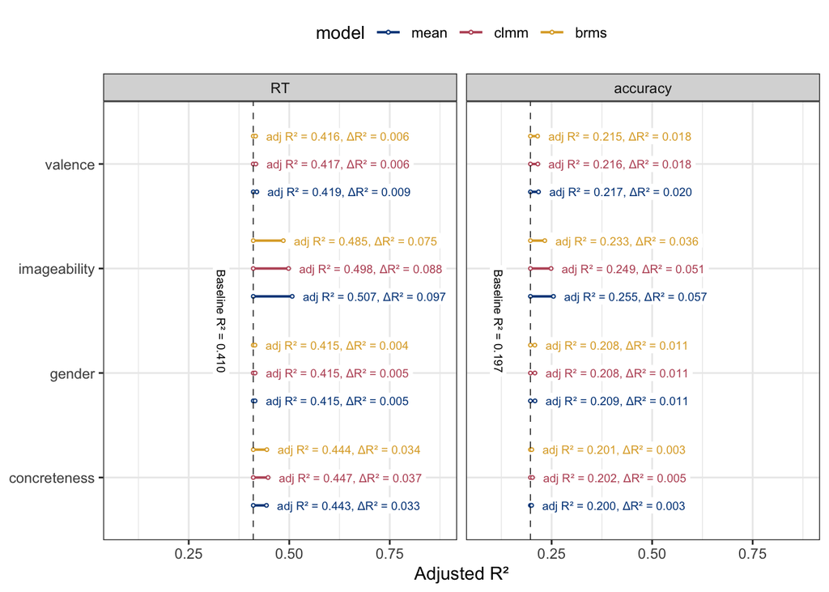

```r
r2_tbl <- rt_r2_tbl %>%
  mutate(predicted = "RT") %>%
  separate(predictor, sep = "_", into = c("model", "predictor")) %>%
  bind_rows(acc_r2_tbl %>%
              mutate(predicted = "accuracy") %>%
              separate(predictor, sep = "_", into = c("model", "predictor"))) %>%
  mutate(r2_label = paste0(" adj R\u00B2 = ", format(round(`R2 adj`, 3), nsmall = 3), ", ΔR\u00B2 = ", format(round(delta_R2, 3), nsmall = 3))) %>%
  mutate(model = factor(model, ordered = TRUE, levels = c("mean", "clmm", "brms")),
         predicted = factor(predicted, ordered = TRUE, levels = c("RT", "accuracy")))

r2_full_plot <- r2_tbl %>%
  ggplot(aes(x = baseline_R2, y = predictor, colour = model)) +
  geom_linerange(data = r2_tbl,
                  aes(xmin = baseline_R2, xmax = `R2 adj`), size = 0.7, position = position_dodge(0.8)) +
  geom_point(size = 0.7, shape = 21, fill = "white", position = position_dodge(0.8)) +
  geom_point(aes(x = `R2 adj`), size = 0.7, shape = 21, fill = "white", position = position_dodge(0.8)) +
  geom_vline(aes(xintercept = baseline_R2), linetype = 2, linewidth = .25) +
  geom_label(aes(x = `R2 adj`, label = r2_label), position = position_dodgenudge(width = 0.8, x = 0.01), size = 2.5, hjust = 0, border.colour = "white", show.legend = FALSE) +
  geom_label(aes(x = baseline_R2-0.08, label = paste0("Baseline R\u00B2 = ", format(round(baseline_R2, 3), nsmall = 3)), colour = NULL), y = 2.5, text.colour = "black", size = 2.5, hjust = 0.5, angle = 270, border.colour = "white", show.legend = FALSE) +
  scale_x_continuous(expand = expansion(mult = c(0.2, 1)), name = "Adjusted R\u00B2") +
  scale_color_manual(values = c("#004488", "#BB5566", "#DDAA33")) +
  facet_wrap(~predicted) +
  theme_bw() +
  theme(legend.position = "top",
        axis.title.y = element_blank())

r2_full_plot
```

```r
ggsave(plot = r2_full_plot, "plots/r2_full_plot.png", height = 4, width = 8, dpi = 400)
```